# Home Credit Default Risk EDA

Author

Sebastian Perez

Published

September 27, 2025

# Introduction

**Business problem:** Home Credit struggles to accurately assess credit risk for applicants with limited financial histories, leading to missed lending opportunities. This project aims to improve the reliability of default predictions for these applicants. The goal is to help the company reduce financial risk by predicting which loan applicants are most likely to default.

**Analytic problem:** The analytic goal is to build a predictive model that uses the available applicant information to estimate the probability of default.

This notebook serves as the first step in addressing Home Credit’s challenge of assessing credit risk for applicants with limited financial histories. Through exploratory data analysis (EDA), we aim to develop a deeper understanding of the dataset, uncover patterns and relationships, and identify variables that may be useful in building predictive models for loan default.

We will be looking out for:

- What are the characteristics of applicants who default versus those who repay?
- Which features show strong correlation with the target variable?
- Are there missing values or outliers that need to be addressed before modeling?
- Do any variables require transformation?

# Description of the data

The Home Credit Default Risk dataset is a comprehensive collection of financial and demographic information used to predict the likelihood that a loan applicant will default. The data is designed to support the development of an accurate and reliable credit scoring model.

# Explore the target variable

We start by loading the necessary libraries and the dataset.

```r
#load libraries
library(tidyverse)
library(VennDiagram)
library(corrplot)
library(naniar)
library(ggvenn)
library(dplyr)
```

```r
train <- read.csv("application_train.csv")
```

We begin to learn about the `TARGET` variable by taking a look at the counts and proportions in the train data.

```r
table(train$TARGET)
```

```
     0      1
282686  24825
```

```r
prop.table(table(train$TARGET))
```

```
         0          1
0.91927118 0.08072882
```

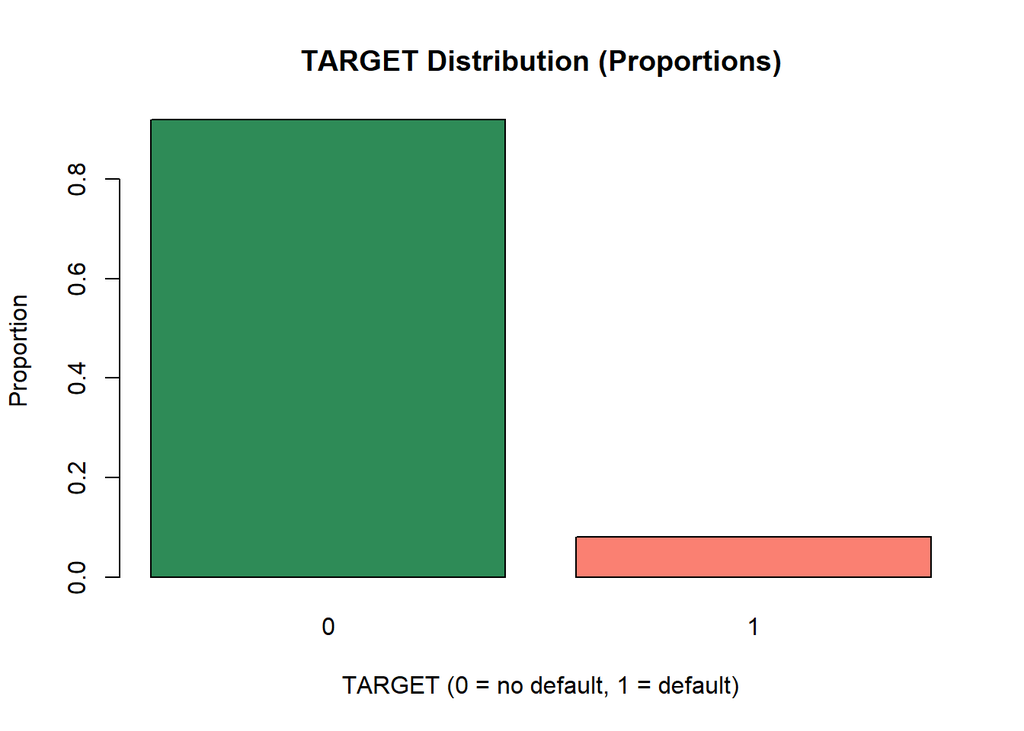

```r
# Bar plot of proportions
barplot(prop.table(table(train$TARGET)),
        main = "TARGET Distribution (Proportions)",
        xlab = "TARGET (0 = no default, 1 = default)",
        ylab = "Proportion",
        col = c("seagreen", "salmon"))
```

This is a highly imbalanced dataset with ~92% of applicants not defaulting. A majority class classifier would always predict no default and its accuracy would be equal to ~92%, the proportion of the majority class. The accuracy of a majority class classifier would be miselading. We couold explore other metrics such as ROC, AUC or precision.

Here is just another visual with a stacked bar instead.

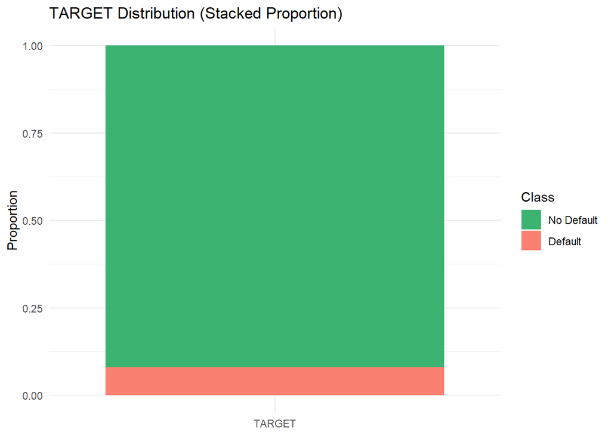

```r
library(ggplot2)

# Create a data frame of proportions
target_df <- as.data.frame(prop.table(table(train$TARGET)))
colnames(target_df) <- c("TARGET", "Proportion")

# Reorder factor levels: 0 (No Default) first
target_df$TARGET <- factor(target_df$TARGET, levels = c("0", "1"))

# Plot stacked bar
ggplot(target_df, aes(x = "TARGET", y = Proportion, fill = factor(TARGET))) +
  geom_bar(stat = "identity") +
  scale_fill_manual(values = c("mediumseagreen", "salmon"),
                    labels = c("No Default", "Default")) +
  labs(title = "TARGET Distribution (Stacked Proportion)",
       x = NULL, y = "Proportion", fill = "Class") +
  theme_minimal()
```

Since the data is highly unbalanced, a model would have trouble learning from the dataset with such a small proportion of defaults.

# Explore the relationship between target and predictors

We use the stacked barplot to visualize predictors against target variables. This provides an easier way to visualize and compare probabilities of default.

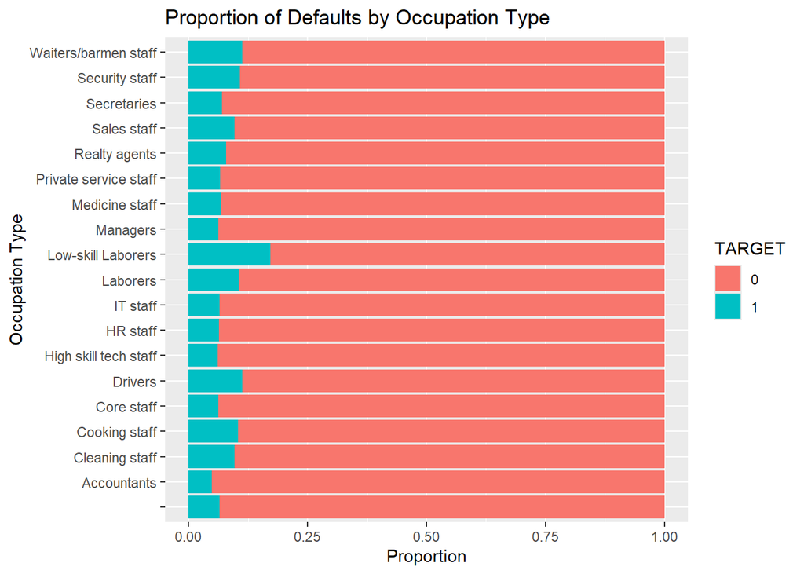

```r
# OCCUPATION and TARGET
ggplot(train, aes(x=OCCUPATION_TYPE, fill=factor(TARGET))) +
  geom_bar(position="fill") +
  labs(title="Proportion of Defaults by Occupation Type",
       x="Occupation Type",
       y="Proportion",
       fill="TARGET") +
  coord_flip()
```

We can see that low-skill laborers have the highest probability of default. Let’s dive in deeper to see the actual numbers.

```r
# Filter rows where OCCUPATION_TYPE is "Low-skill Laborers"
low_skill <- train[train$OCCUPATION_TYPE == "Low-skill Laborers", ]

# Calculate default rate (TARGET = 1)
round(mean(low_skill$TARGET, na.rm = TRUE), 2)*100
```

```
[1] 17
```

Almost a fifth of low-skill laborers tend to default. This is a high probabiilty amongst the other occupation types.

Now, let’s compare proportions of default among income types.

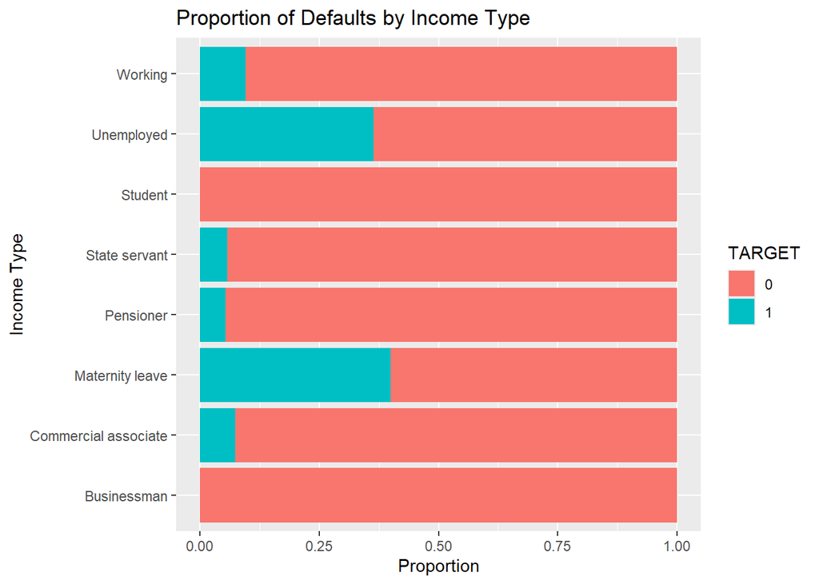

```r
# INCOME and TARGET
ggplot(train, aes(x=NAME_INCOME_TYPE, fill=factor(TARGET))) +
  geom_bar(position="fill") +
  labs(title="Proportion of Defaults by Income Type",
       x="Income Type",
       y="Proportion",
       fill="TARGET") +
  coord_flip()
```

Something interesting to highlight is that students and businessmen seem to not default. We may expect the unemployed to have a higher probability of defaulting while women on maternity leave wasn’t in the radar.

We now check to see how incomes are distributed over the target variable.

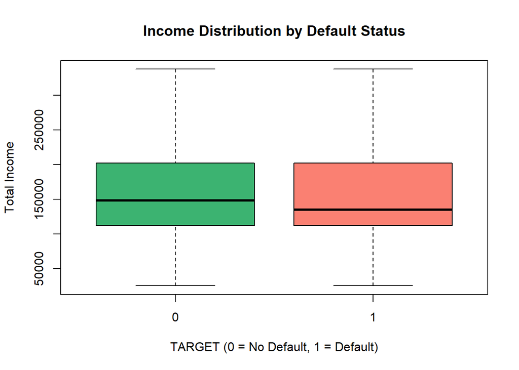

```r
boxplot(AMT_INCOME_TOTAL ~ TARGET, data = train,
        main = "Income Distribution by Default Status",
        xlab = "TARGET (0 = No Default, 1 = Default)",
        ylab = "Total Income",
        col = c("mediumseagreen", "salmon"),
        outline = FALSE)
```

The distribution of incomes between default and no default have very similar ranges. Income does not seem to influence the outcome as much as expected.

Now let’s explore the differences between education levels:

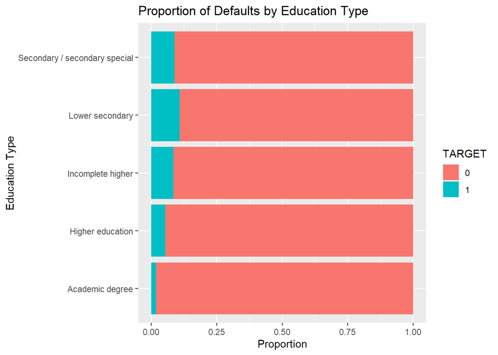

```r
# EDUCATION and TARGET
ggplot(train, aes(x=NAME_EDUCATION_TYPE, fill=factor(TARGET))) +
  geom_bar(position="fill") +
  labs(title="Proportion of Defaults by Education Type",
       x="Education Type",
       y="Proportion",
       fill="TARGET") +
  coord_flip()
```

This supports the idea of highly educated individuals defaults much less than the rest of the individuals with lower academic backgrounds.

Let’s explore and see if having a car is a potential predictor for credit default.

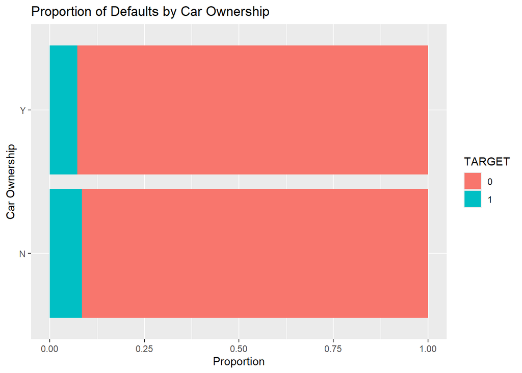

```r
ggplot(train, aes(x=FLAG_OWN_CAR, fill=factor(TARGET))) +
  geom_bar(position="fill") +
  labs(title="Proportion of Defaults by Car Ownership",
       x="Car Ownership",
       y="Proportion",
       fill="TARGET") +
  coord_flip()
```

There seems to be no relationship of owning a car and credit default.

Let’s explore and see if owning a property is a potential predictor for credit default.

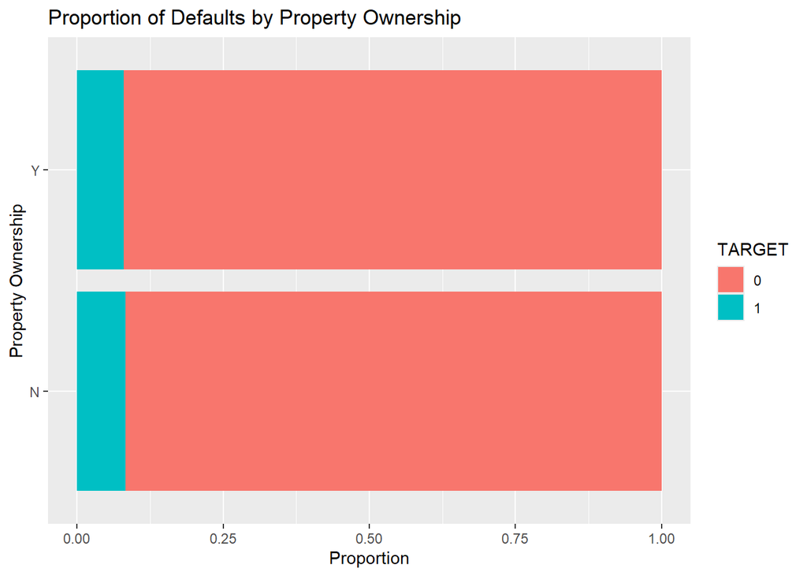

```r
ggplot(train, aes(x=FLAG_OWN_REALTY, fill=factor(TARGET))) +
  geom_bar(position="fill") +
  labs(title="Proportion of Defaults by Property Ownership",
       x="Property Ownership",
       y="Proportion",
       fill="TARGET") +
  coord_flip()
```

Let’s explore and see if organization type where the client works is a potential predictor for credit default.

[figure not shown]

```r
# ORGANIZATION TYPE and TARGET
ggplot(train, aes(x=FLAG_OWN_REALTY, fill=factor(TARGET))) +
  geom_bar(position="fill") +
  labs(title="Proportion of Defaults by Organization Type",
       x="OrganizationType",
       y="Proportion",
       fill="TARGET") +
  coord_flip()
```

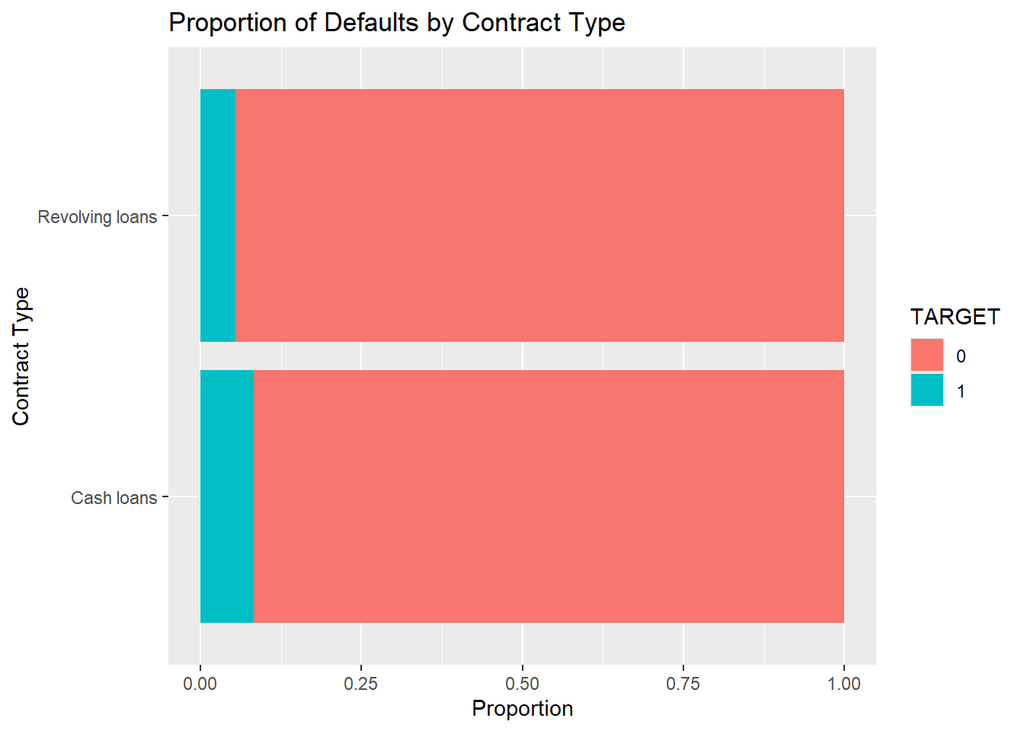

```r
# CONTRACT TYPE and TARGET
ggplot(train, aes(x=NAME_CONTRACT_TYPE, fill=factor(TARGET))) +
  geom_bar(position="fill") +
  labs(title="Proportion of Defaults by Contract Type",
       x="Contract Type",
       y="Proportion",
       fill="TARGET") +
  coord_flip()
```

Cash loans seem to be a reason for larger likelihood of default. Contract type seems to be a good predictor for default.

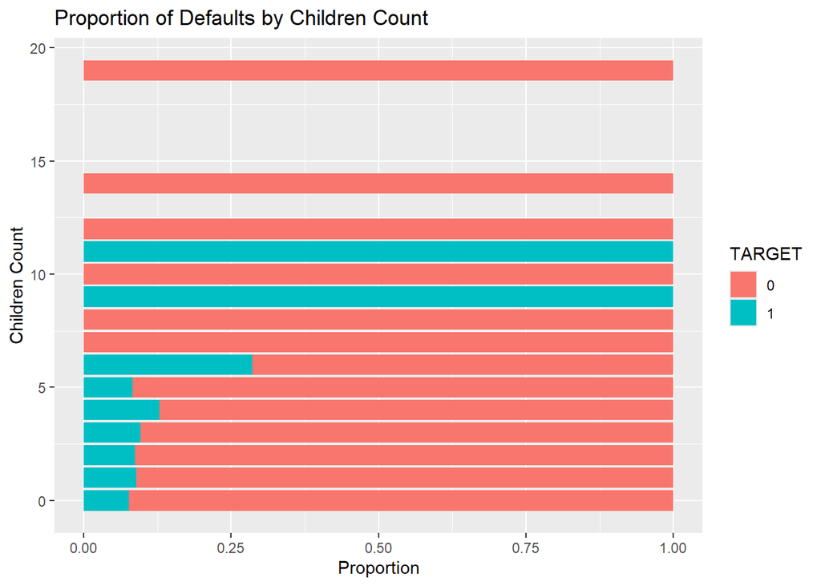

```r
# CHILDREN COUNT and TARGET
ggplot(train, aes(x=CNT_CHILDREN, fill=factor(TARGET))) +
  geom_bar(position="fill") +
  labs(title="Proportion of Defaults by Children Count",
       x="Children Count",
       y="Proportion",
       fill="TARGET") +
  coord_flip()
```

It seems like having 5+ children may increase the probability of default. This could be a potential predictor to include in our model.

Let explore default for credit amount.

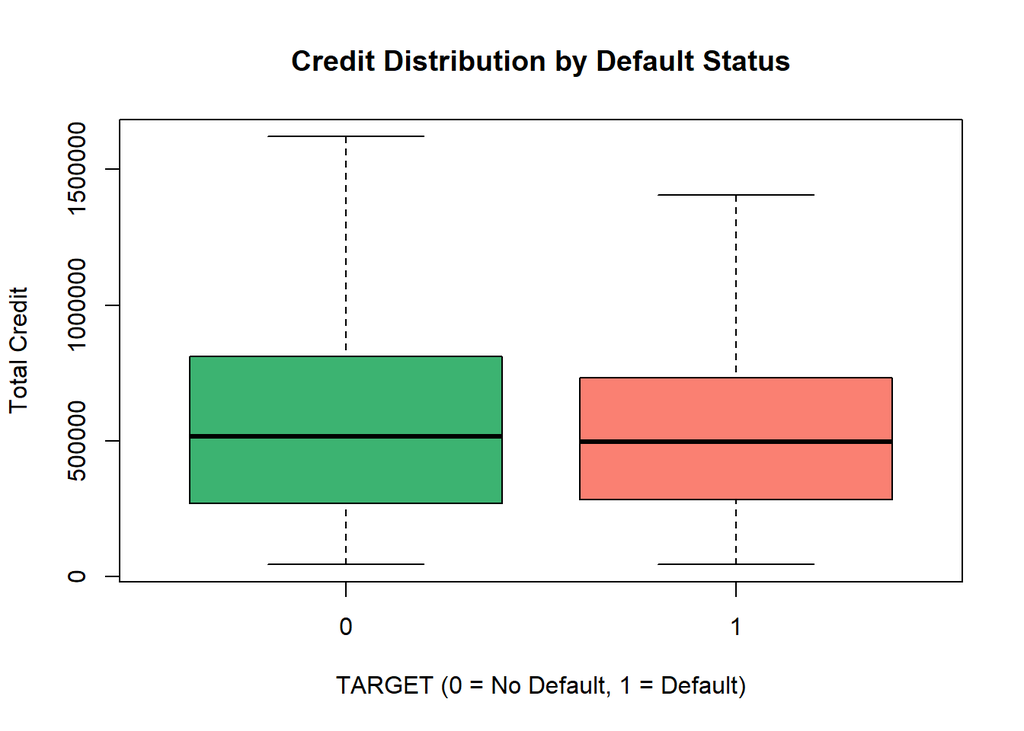

```r
boxplot(AMT_CREDIT ~ TARGET, data = train,
        main = "Credit Distribution by Default Status",
        xlab = "TARGET (0 = No Default, 1 = Default)",
        ylab = "Total Credit",
        col = c("mediumseagreen", "salmon"),
        outline = FALSE)
```

It appears that higher lenders tend less to be defaulters. We could explore this variable more testing it in modeling.

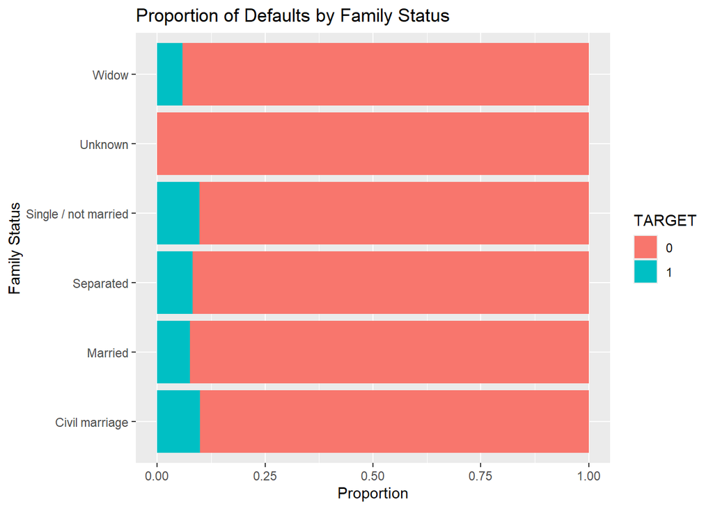

```r
# FAMILY STATUS and TARGET
ggplot(train, aes(x=NAME_FAMILY_STATUS, fill=factor(TARGET))) +
  geom_bar(position="fill") +
  labs(title="Proportion of Defaults by Family Status",
       x="Family Status",
       y="Proportion",
       fill="TARGET") +
  coord_flip()
```

There are subtle differences in family status that may indicate that this variable may be telling us something more about default.

Lets look into housing type.

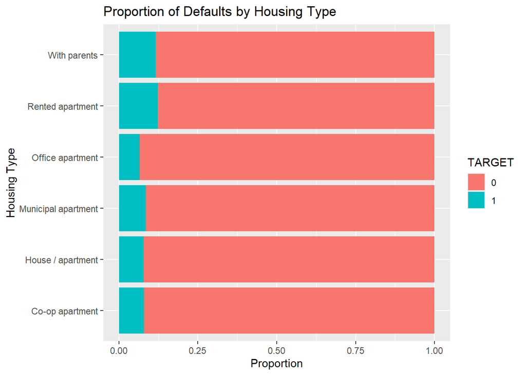

```r
ggplot(train, aes(x=NAME_HOUSING_TYPE, fill=factor(TARGET))) +
  geom_bar(position="fill") +
  labs(title="Proportion of Defaults by Housing Type",
       x="Housing Type",
       y="Proportion",
       fill="TARGET") +
  coord_flip()
```

This differences may have statistical meaning to them. We could model it too.

Let dive into tenure.

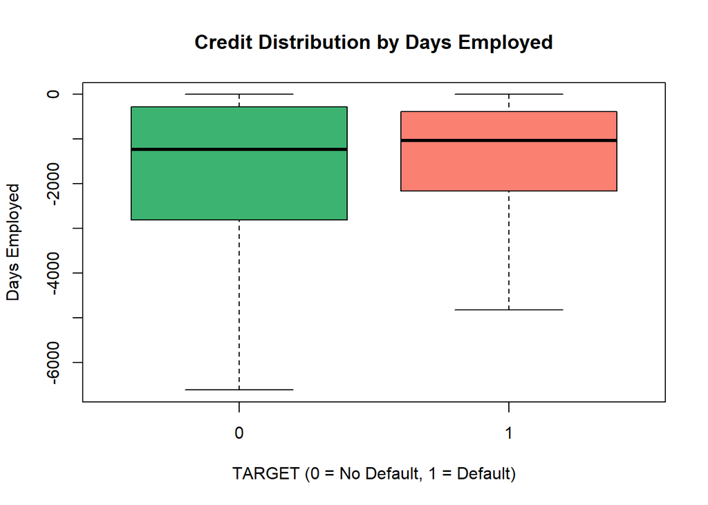

```r
boxplot(DAYS_EMPLOYED ~ TARGET, data = train,
        main = "Credit Distribution by Days Employed",
        xlab = "TARGET (0 = No Default, 1 = Default)",
        ylab = "Days Employed",
        col = c("mediumseagreen", "salmon"),
        outline = FALSE)
```

Let’s look into gender,

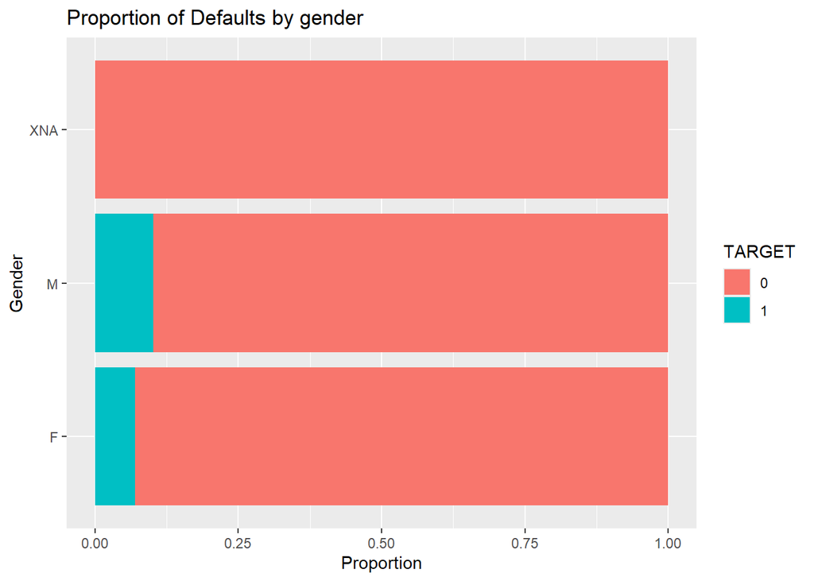

```r
ggplot(train, aes(x=CODE_GENDER, fill=factor(TARGET))) +
  geom_bar(position="fill") +
  labs(title="Proportion of Defaults by gender",
       x="Gender",
       y="Proportion",
       fill="TARGET") +
  coord_flip()
```

It seems that males are the largest defaulters. One consideration could be that men also get more loans than women.

Finally, let’s look at age vs outcome.

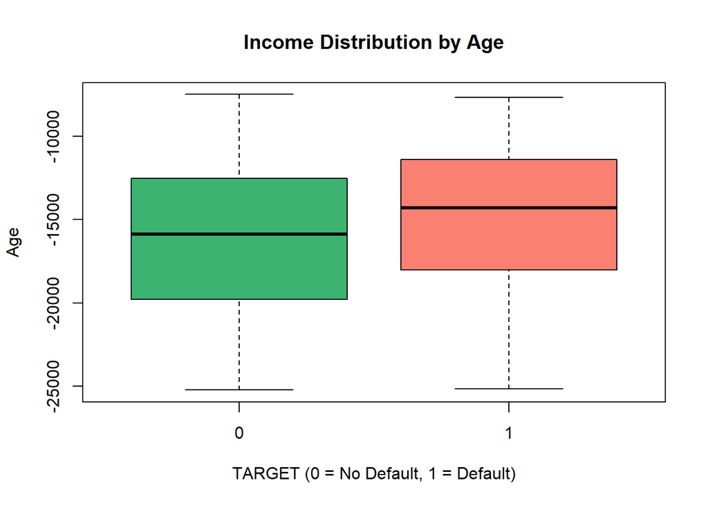

```r
boxplot(DAYS_BIRTH ~ TARGET, data = train,
        main = "Income Distribution by Age",
        xlab = "TARGET (0 = No Default, 1 = Default)",
        ylab = "Age",
        col = c("mediumseagreen", "salmon"),
        outline = FALSE)
```

Numeric variable which can give highlights on defaulting.

# Feature Exploration: AI vs. Human

🗣 **Prompt to AI:** Act as a credit risk analyst. Based only on the column names and descriptions from the data dictionary, identify the top 15–20 variables you believe would be most predictive of the TARGET variable (loan default). Do not use any data, just the semantic meaning of the features.

💡 **AI’s response:**

AMT_INCOME_TOTAL: Total income of the applicant

AMT_CREDIT: Amount of credit applied for

NAME_CONTRACT_TYPE: Type of loan contract

DAYS_EMPLOYED: Days since employment began

OCCUPATION_TYPE: Applicant’s occupation

EXT_SOURCE_1, EXT_SOURCE_2, EXT_SOURCE_3: External risk scores

CNT_CHILDREN: Number of children

NAME_EDUCATION_TYPE: Education level

NAME_FAMILY_STATUS: Marital status

REGION_RATING_CLIENT: Regional risk rating

FLAG_OWN_CAR, FLAG_OWN_REALTY: Asset ownership

DAYS_BIRTH: Age of applicant

CODE_GENDER: Gender

CNT_FAM_MEMBERS: Family size

NAME_INCOME_TYPE: Source of income

⚠️ **Critique of AI’s reasoning:**

Some variables like CODE_GENDER or FLAG_OWN_CAR may have weak predictive power or ethical concerns.

The AI did not consider feature redundancy or multicollinearity.

It lacked nuance around temporal variables (e.g., DAYS_EMPLOYED vs. DAYS_BIRTH).

We don’t know how the variables EXT_SOURCE_1, EXT_SOURCE_2, EXT_SOURCE_3 were calculated with the possibility of influencing default without knowing exactly how.

**Variable Comparison:**

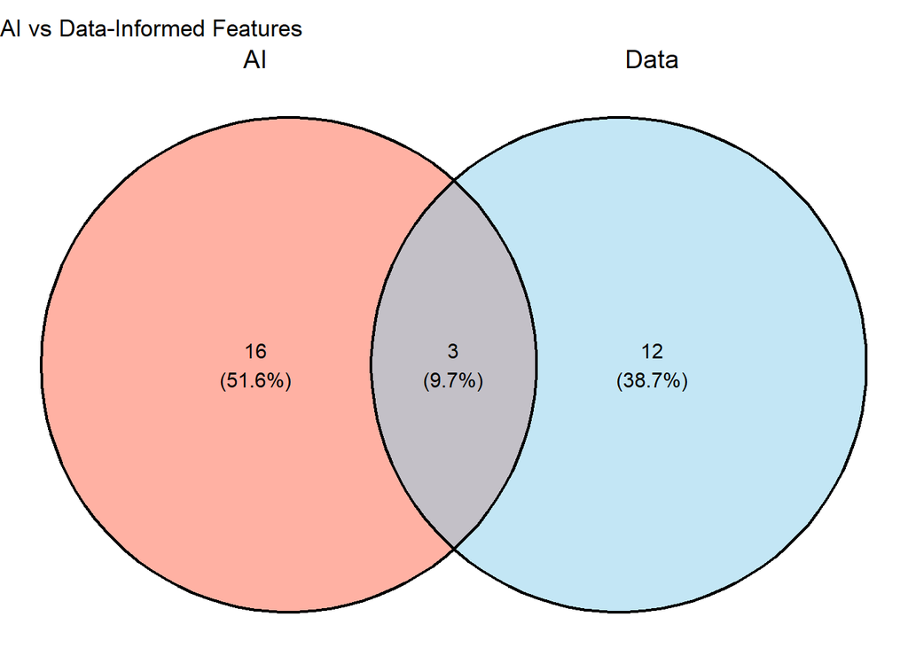

```r
ai_list   <- c("INCOME",
  "CREDIT_AMOUNT",
  "CONTRACT_TYPE",
  "DAYS_EMPLOYED",
  "OCCUPATION_TYPE",
  "EXT_SOURCE_1",
  "EXT_SOURCE_2",
  "EXT_SOURCE_3",
  "CHILDREN_COUNT",
  "EDUCATION",
  "FAMILY_STATUS",
  "REGION_RATING",
  "OWN_CAR",
  "OWN_REALTY",
  "DAYS BIRTH",
  "GENDER",
  "FAMILY_SIZE",
  "INCOME_TYPE",
  "AMT_ANNUITY")

data_list <- c("OCCUPATION_TYPE", "DAYS BIRTH",
  "NAME_INCOME_TYPE",
  "AMT_INCOME_TOTAL",
  "NAME_EDUCATION_TYPE",
  "FLAG_OWN_CAR",
  "FLAG_OWN_REALTY",
  "ORGANIZATION_TYPE",
  "NAME_CONTRACT_TYPE",
  "CNT_CHILDREN",
  "AMT_CREDIT",
  "NAME_FAMILY_STATUS",
  "NAME_HOUSING_TYPE",
  "DAYS_EMPLOYED",
  "CODE_GENDER",
  "DAYS BIRTH")

ggvenn(
  list(AI = ai_list, Data = data_list),
  fill_color = c("tomato", "skyblue"),
  fill_alpha = 0.5,
  stroke_size = 0.8,
  set_name_size = 5
) + ggtitle("AI vs Data-Informed Features")
```

# Missing data/cleaning the data

Missing data may be crucial to our analysis. If there is too many missing values from significantly important and potential predictor variables, this may be misrepresenting the data and thus our calculations.

Let’s explore the variables with missing data:

```r
# Count missing values per column
missing_counts <- colSums(is.na(train))

# Sort from highest to lowest
sort(missing_counts[missing_counts > 0], decreasing = TRUE)
```

```
              COMMONAREA_AVG              COMMONAREA_MODE
                      214865                       214865
             COMMONAREA_MEDI      NONLIVINGAPARTMENTS_AVG
                      214865                       213514
    NONLIVINGAPARTMENTS_MODE     NONLIVINGAPARTMENTS_MEDI
                      213514                       213514
        LIVINGAPARTMENTS_AVG        LIVINGAPARTMENTS_MODE
                      210199                       210199
       LIVINGAPARTMENTS_MEDI                FLOORSMIN_AVG
                      210199                       208642
              FLOORSMIN_MODE               FLOORSMIN_MEDI
                      208642                       208642
             YEARS_BUILD_AVG             YEARS_BUILD_MODE
                      204488                       204488
            YEARS_BUILD_MEDI                  OWN_CAR_AGE
                      204488                       202929
                LANDAREA_AVG                LANDAREA_MODE
                      182590                       182590
               LANDAREA_MEDI             BASEMENTAREA_AVG
                      182590                       179943
           BASEMENTAREA_MODE            BASEMENTAREA_MEDI
                      179943                       179943
                EXT_SOURCE_1            NONLIVINGAREA_AVG
                      173378                       169682
          NONLIVINGAREA_MODE           NONLIVINGAREA_MEDI
                      169682                       169682
               ELEVATORS_AVG               ELEVATORS_MODE
                      163891                       163891
              ELEVATORS_MEDI               APARTMENTS_AVG
                      163891                       156061
             APARTMENTS_MODE              APARTMENTS_MEDI
                      156061                       156061
               ENTRANCES_AVG               ENTRANCES_MODE
                      154828                       154828
              ENTRANCES_MEDI               LIVINGAREA_AVG
                      154828                       154350
             LIVINGAREA_MODE              LIVINGAREA_MEDI
                      154350                       154350
               FLOORSMAX_AVG               FLOORSMAX_MODE
                      153020                       153020
              FLOORSMAX_MEDI  YEARS_BEGINEXPLUATATION_AVG
                      153020                       150007
YEARS_BEGINEXPLUATATION_MODE YEARS_BEGINEXPLUATATION_MEDI
                      150007                       150007
              TOTALAREA_MODE                 EXT_SOURCE_3
                      148431                        60965
  AMT_REQ_CREDIT_BUREAU_HOUR    AMT_REQ_CREDIT_BUREAU_DAY
                       41519                        41519
  AMT_REQ_CREDIT_BUREAU_WEEK    AMT_REQ_CREDIT_BUREAU_MON
                       41519                        41519
   AMT_REQ_CREDIT_BUREAU_QRT   AMT_REQ_CREDIT_BUREAU_YEAR
                       41519                        41519
    OBS_30_CNT_SOCIAL_CIRCLE     DEF_30_CNT_SOCIAL_CIRCLE
                        1021                         1021
    OBS_60_CNT_SOCIAL_CIRCLE     DEF_60_CNT_SOCIAL_CIRCLE
                        1021                         1021
                EXT_SOURCE_2              AMT_GOODS_PRICE
                         660                          278
                 AMT_ANNUITY              CNT_FAM_MEMBERS
                          12                            2
      DAYS_LAST_PHONE_CHANGE
                           1
```

We can also visualize this for more interpretation (although differences between which variable is which may be complicated).

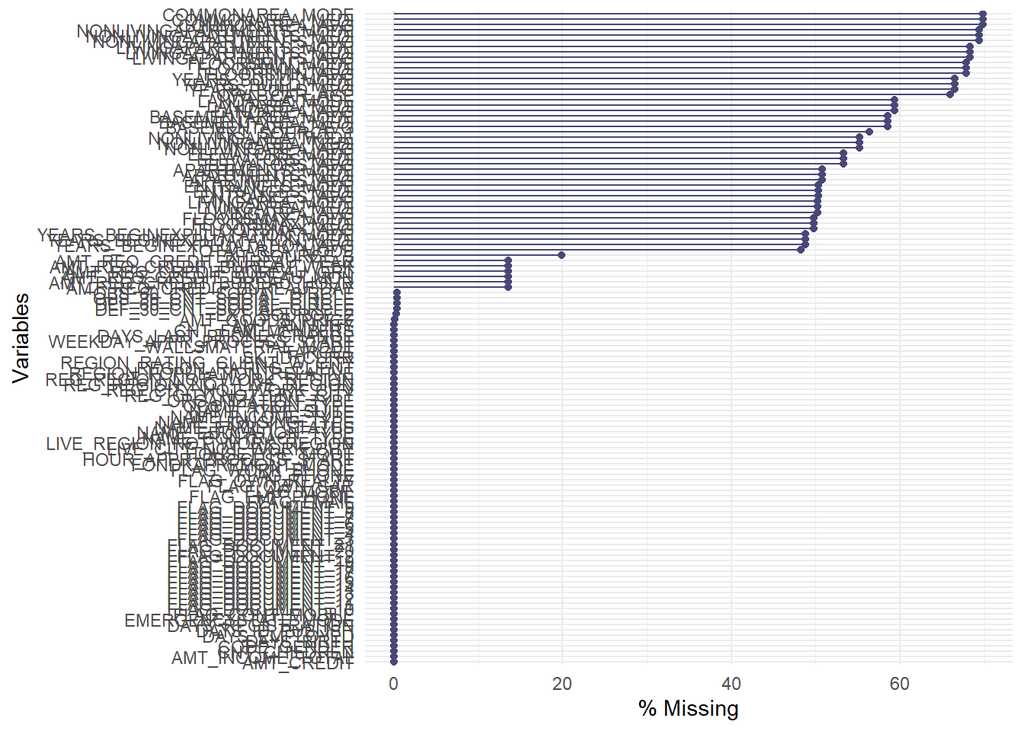

```r
# Visualize missing data
gg_miss_var(train, show_pct = TRUE)
```

This comes to prove that a significant portion of the variables have 10%+ missing values.

We could account for missing data as follows:

Low missingness (<5%) → Impute with median or mean

Moderate missingness (5–30%) → We may consider KNN imputation or regression-based imputation

High missingness (>30%) → We should drop the variable unless it’s critical

**Categorical Variables** Impute with mode or create a new category like “Unknown”

After cleaning our data, we can then test if these cleaned features correlate with TARGET.

There are variables such as days employed which carry a few outliers which if they could be confirmed with the client, could be included or updated.

# Summary of results

The initial exploration of the Home Credit dataset revealed several important insights and challenges. First, the target variable is highly imbalanced—only about 8% of applicants default, which means that standard accuracy metrics may be misleading. To properly evaluate model performance, we’ll need to rely on metrics like AUC, recall, and precision, which are better suited for imbalanced classification problems.

Overall, the EDA highlights both the richness and complexity of the data. A successful modeling approach will need to balance predictive power with fairness, interpretability, and resilience to noise and imbalance.